{% raw %}

{% endraw %} {% raw %}

{% endraw %} {% raw %}

{% endraw %}

The criteria implemented come from [this paper](https://arxiv.org/pdf/1905.01067.pdf).

{% raw %}

`class` `Criteria`[[source]](https://github.com/nathanhubens/fasterai/tree/master/fasterai/sparse/criteria.py#L17)

> `Criteria`(**`f`**, **`needs_init`**=*`False`*, **`needs_update`**=*`False`*, **`output_f`**=*`None`*, **`return_init`**=*`False`*)

{% endraw %} {% raw %}

{% endraw %}

## Weight Based Criteria

### Random

{% raw %}

{% endraw %} {% raw %}

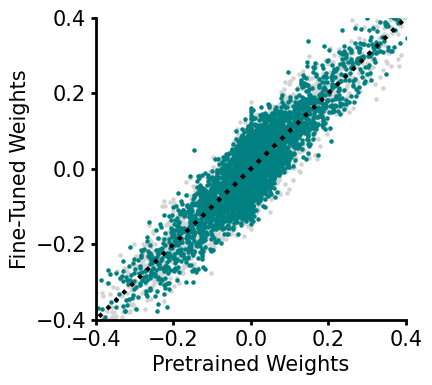

```python
demo_model(random)
```

{% endraw %}

### Large Final Value

{% raw %}

{% endraw %} {% raw %}

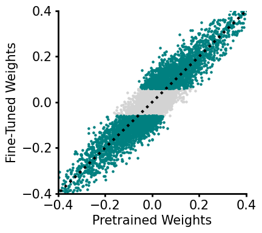

```python
demo_model(large_final)
```

{% endraw %}

### Squared Final Value

{% raw %}

{% endraw %} {% raw %}

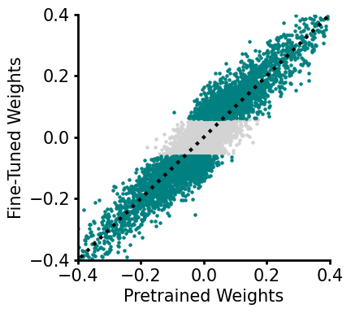

```python
demo_model(squared_final)
```

{% endraw %}

### Small Final Value

{% raw %}

{% endraw %} {% raw %}

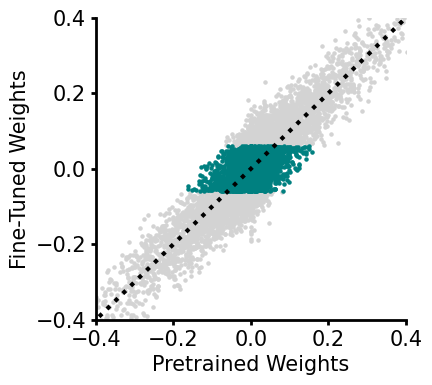

```python
demo_model(small_final)
```

{% endraw %}

### Large Init Value

{% raw %}

{% endraw %} {% raw %}

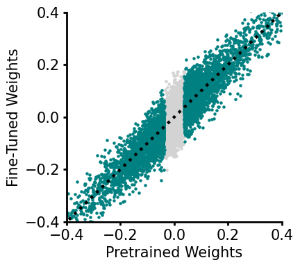

```python
demo_model(large_init)
```

{% endraw %}

### Small Init Value

{% raw %}

{% endraw %} {% raw %}

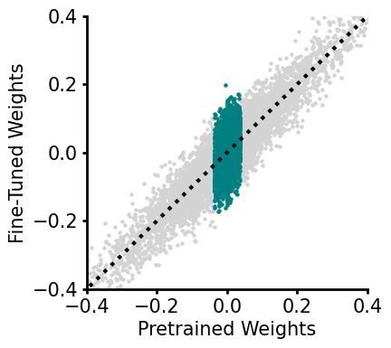

```python
demo_model(small_init)
```

{% endraw %}

### Large Init Large Final Value

{% raw %}

{% endraw %} {% raw %}

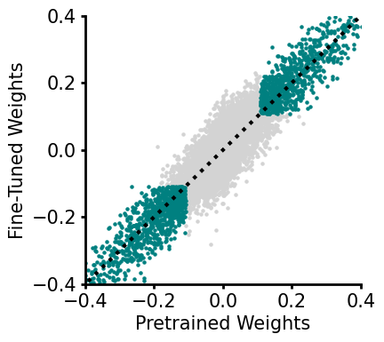

```python
demo_model(large_init_large_final, 80)
```

{% endraw %}

### Small Init Small Final Value

{% raw %}

{% endraw %} {% raw %}

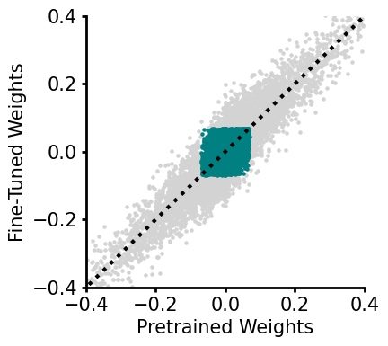

```python
demo_model(small_init_small_final)
```

{% endraw %}

### Increasing Magnitude

{% raw %}

{% endraw %} {% raw %}

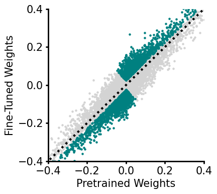

```python
demo_model(magnitude_increase, 60)
```

{% endraw %}

### Movement Pruning

{% raw %}

{% endraw %} {% raw %}

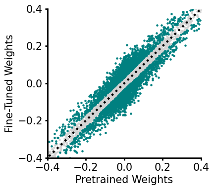

```python
demo_model(movement)
```

{% endraw %}

## Updating Versions

The following criteria use an updating value of the weights, i.e. the value from the previous iteration of training, instead of the initialization value to better capture the training dynamics.

### Updating Magnitude Increase

{% raw %}

{% endraw %} {% raw %}

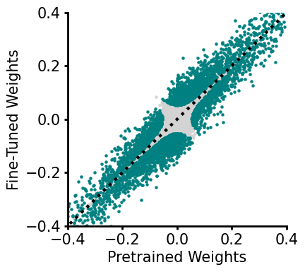

```python
demo_model(updating_magnitude_increase)
```

{% endraw %}

### Updating Movement

{% raw %}

{% endraw %} {% raw %}

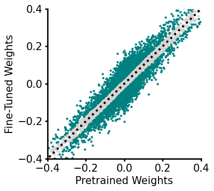

```python
demo_model(updating_movement, 50)
```

{% endraw %}

### mov-magnitude

{% raw %}

{% endraw %} {% raw %}

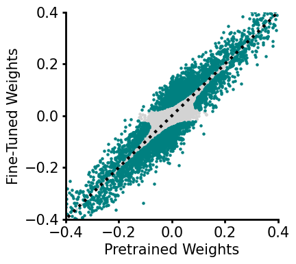

```python
demo_model(movmag)
```

{% endraw %}

### Updating mov-magnitude

{% raw %}

{% endraw %} {% raw %}

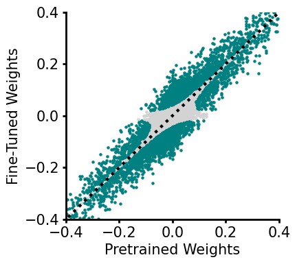

```python
demo_model(updating_movmag)
```

{% endraw %} {% raw %}

`available_criterias`[[source]](https://github.com/nathanhubens/fasterai/tree/master/fasterai/sparse/criteria.py#L102)

> `available_criterias`()

{% endraw %} {% raw %}

{% endraw %}

# New Ideas

{% raw %}

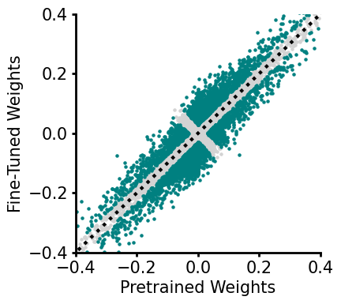

```python
updating_magnitude_increase = Criteria(torch.abs, needs_update=True, output_f= lambda x,y: torch.abs(torch.sub(x,y)))

demo_model(updating_magnitude_increase)
```

{% endraw %} {% raw %}

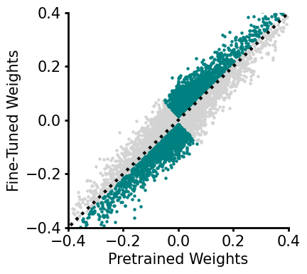

```python
updating_magnitude_increase = Criteria(torch.abs, needs_update=True, output_f= lambda x,y: torch.sub(x,y))

demo_model(updating_magnitude_increase)
```

{% endraw %} {% raw %}

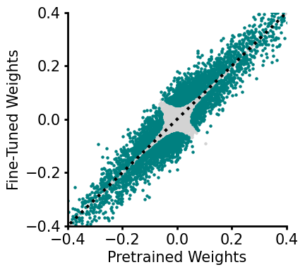

```python
updating_magnitude_increase = Criteria(torch.square, needs_update=True, output_f= lambda x,y: torch.abs(torch.sub(x,y)))

demo_model(updating_magnitude_increase)
```

{% endraw %} {% raw %}

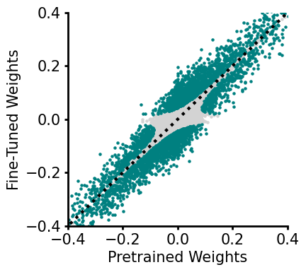

```python
updating_movmag = Criteria(noop, needs_update=True, output_f=lambda x,y: torch.abs(torch.mul(x, torch.sub(x,y))))
demo_model(updating_movmag)
```

{% endraw %} {% raw %}

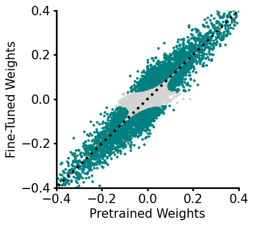

```python
updating_movmag = Criteria(noop, needs_update=True, output_f=lambda x,y: torch.abs(torch.mul(torch.square(x), torch.sub(x,y))))
demo_model(updating_movmag)
```

{% endraw %} {% raw %}

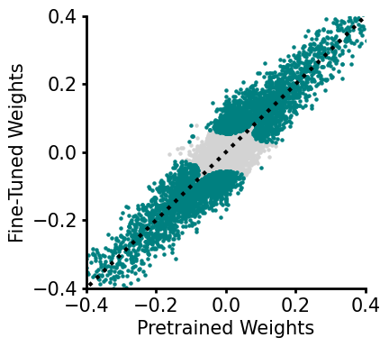

```python
updating_movmag = Criteria(torch.square, needs_update=True, output_f=lambda x,y: torch.abs(torch.mul(x, torch.sub(x,y))))
#updating_movmag = Criteria(noop, needs_update=True, output_f=lambda x,y: torch.mul(x, torch.sub(x,y)))
demo_model(updating_movmag)
```

{% endraw %} {% raw %}

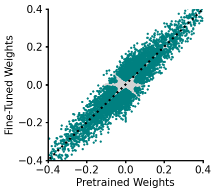

```python
updating_movmag = Criteria(torch.abs, needs_update=True, output_f=lambda x,y: torch.abs(torch.mul(x, torch.sub(x,y))))
#updating_movmag = Criteria(noop, needs_update=True, output_f=lambda x,y: torch.mul(x, torch.sub(x,y)))
demo_model(updating_movmag, 30)
```

{% endraw %} {% raw %}

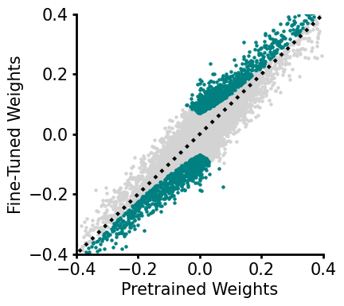

```python
updating_movmag = Criteria(torch.abs, needs_update=True, output_f=lambda x,y: torch.mul(x, torch.sub(x,y)))

demo_model(updating_movmag, 80)
```

{% endraw %} {% raw %}

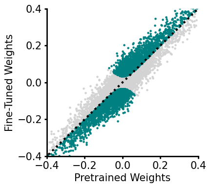

```python
updating_movmag = Criteria(torch.square, needs_update=True, output_f=lambda x,y: torch.mul(x, torch.sub(x,y)))

demo_model(updating_movmag)
```

{% endraw %} {% raw %}

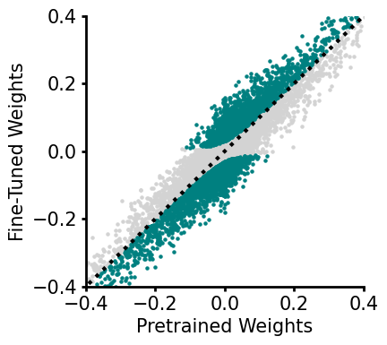

```python
updating_movmag = Criteria(noop, needs_update=True, output_f=lambda x,y: torch.mul(x, torch.sub(x,y)))

demo_model(updating_movmag)
```

{% endraw %} {% raw %}

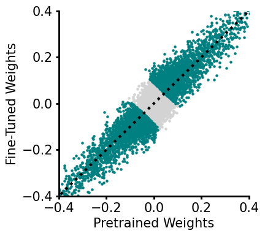

```python
updating_movement = Criteria(noop, needs_update=True, output_f= lambda x,y: torch.abs(torch.sub(-x,y)))
demo_model(updating_movement, 50)
```

{% endraw %} {% raw %}

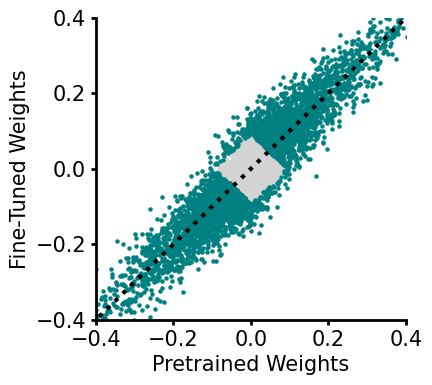

```python
updating_movement = Criteria(torch.abs, needs_update=True, output_f= lambda x,y: torch.abs(torch.sub(-x,y)))
demo_model(updating_movement)
```

{% endraw %} {% raw %}

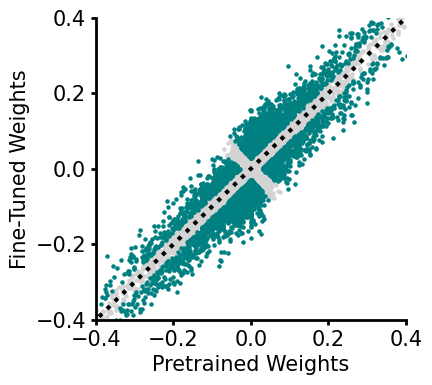

```python
updating_movement = Criteria(torch.abs, needs_update=True, output_f= lambda x,y: torch.abs(torch.cosh(torch.sub(x,y))))
demo_model(updating_movement)
```

{% endraw %} {% raw %}

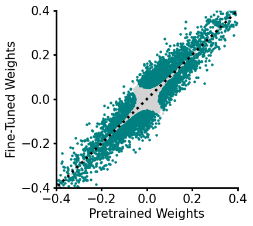

```python
updating_movement = Criteria(torch.square, needs_update=True, output_f= lambda x,y: torch.abs(torch.sub(x,y)))
demo_model(updating_movement)
```

{% endraw %} {% raw %}

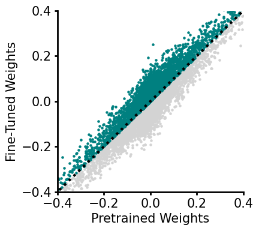

```python
updating_movement = Criteria(noop, needs_update=True, output_f= lambda x,y: torch.sub(x,y))
demo_model(updating_movement)
```

{% endraw %} {% raw %}

```python
mine = partial(torch.pow, exponent=4)
```

{% endraw %} {% raw %}

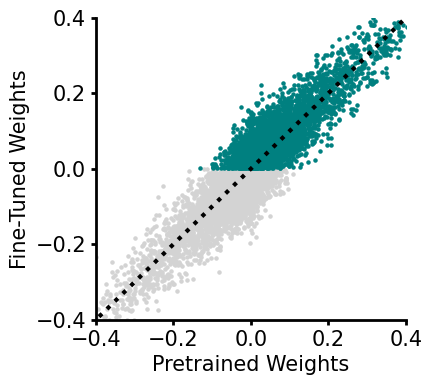

```python
large_final = Criteria(torch.frac)
demo_model(large_final)
```

{% endraw %}

### First order Taylor expansion on the weight (as per [Nvidia Taylor Pruning](https://github.com/NVlabs/Taylor_pruning/blob/master/pruning_engine.py))

{% raw %}

`grad_crit`[[source]](https://github.com/nathanhubens/fasterai/tree/master/fasterai/sparse/criteria.py#L106)

> `grad_crit`(**`m`**, **`g`**)

{% endraw %} {% raw %}

{% endraw %}